# Question

Curve $y=f[x]$ contains points $(0,3)$ and $(2,5)$ and $(5,1)$, as shown on the $x$-$y$ plane below.

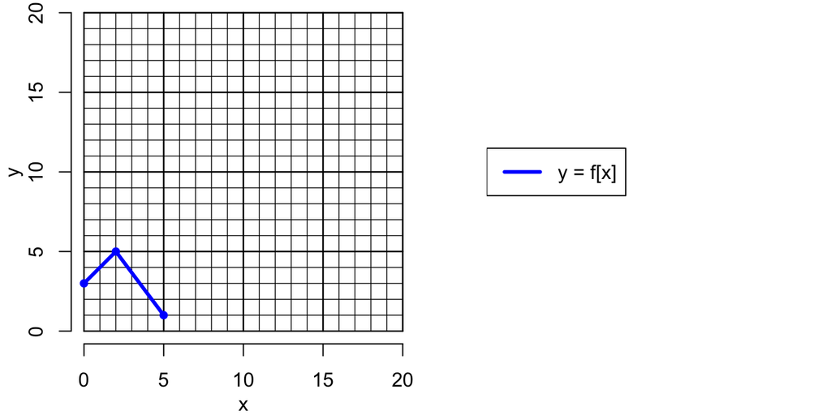

In other words:
$$f[0]=3$$
$$f[2]=5$$
$$f[5]=1$$

Let function $g$ be a transformation of function $f$, as defined by the equation below:

$$g[x]~=~3\cdot
f{\left[\frac{x}{2}-4\right]}+3$$

Find the three corresponding points of curve $y=g[x]$.

[output not shown]

## Answerlist

- 0
- 1
- 2
- 4
- 5
- 6
- 8
- 10
- 12
- 18
- 0
- 1
- 2
- 4
- 5
- 6
- 8
- 10
- 12
- 18
- 0
- 1
- 2
- 4
- 5
- 6
- 8
- 10
- 12
- 18
- 0
- 1
- 2
- 4
- 5
- 6
- 8
- 10
- 12
- 18
- 0
- 1
- 2
- 4
- 5
- 6
- 8
- 10
- 12
- 18
- 0
- 1
- 2
- 4
- 5
- 6
- 8
- 10
- 12
- 18

# Solution

| $x$ | $g[x]$ |
| --- | --- |
| 8 | 12 |
| 12 | 18 |
| 18 | 6 |

**How to get the answers…**

Rewrite the given information:
$$f[0]=3$$
$$f[2]=5$$
$$f[5]=1$$
$$g[x]=3\cdot
f{\left[\frac{x}{2}-4\right]}+3$$

1. Use $f[0]=3$.
   - Set the argument of $f$ equal to 0.
     $$\frac{x}{2}-4=0$$
     Solve the two-step equation.
     $$x=8$$
     Substitute 8 for $x$ in the main equation.
     $$g[8]=3\cdot
     f{\left[\frac{8}{2}-4\right]}+3$$
     Simplify the argument.
     $$g[8]=3\cdot f{\left[0\right]}+3$$
     Substitute 3 for $f[0]$ because $f[0]=3$.
     $$g[8]=3\cdot 3+3$$
     Use arithmetic to evaluate the numerical expression.
     $$g[8]=12$$
     So our first new point on $y=g(x)$ is point $(8,12)$.
2. Use old point = $(2,5)$. So, use $f[2]=5$.
   - Set the argument of $f$ equal to 2.
     $$\frac{x}{2}-4=2$$
     Solve the two-step equation.
     $$x=12$$
     Substitute 12 for $x$ in the main equation.
     $$g[12]=3\cdot
     f{\left[\frac{12}{2}-4\right]}+3$$
     Simplify the argument.
     $$g[12]=3\cdot f{\left[2\right]}+3$$
     Substitute 5 for $f[2]$ because $f[2]=5$.
     $$g[12]=3\cdot 5+3$$
     Use arithmetic to evaluate the numerical expression.
     $$g[12]=18$$
     So our second new point on $y=g(x)$ is point $(12,18)$.
3. Use old point = $(5,1)$. So, use $f[5]=1$.
   - Set the argument of $f$ equal to 5.
     $$\frac{x}{2}-4=5$$
     Solve the two-step equation.
     $$x=18$$
     Substitute 18 for $x$ in the main equation.
     $$g[18]=3\cdot
     f{\left[\frac{18}{2}-4\right]}+3$$
     Simplify the argument.
     $$g[18]=3\cdot f{\left[5\right]}+3$$
     Substitute 1 for $f[5]$ because $f[5]=1$.
     $$g[18]=3\cdot 1+3$$
     Use arithmetic to evaluate the numerical expression.
     $$g[18]=6$$
     So our third new point on $y=g(x)$ is point $(18,6)$.

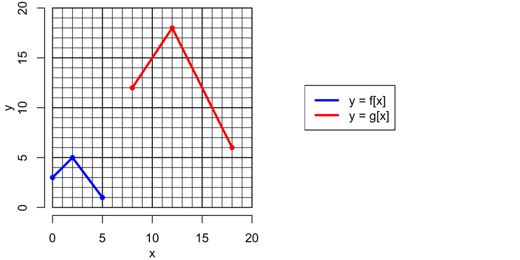

**Shortcut…**

You can save a lot of time by recognizing the following:

- The new $x$ values are found using the INVERSE of the argument expression. Remember, the expression in the argument was $\frac{x}{2}-4$, so:
  - $$x_{\text{new}}~=~2\cdot\left(x_{\text{old}}+4\right)$$
- The new $y$ values are found using the operations outside the function. It might help to see the original expression with an abbreviated argument: $3\cdot f[\text{arg}]+3$
  - $$y_{\text{new}}~=~3\cdot
    y_{\text{old}}+3$$

# Meta-information

extype: cloze exclozetype: schoice|schoice|schoice|schoice|schoice|schoice exsolution: 0000001000|0000000010|0000000001|0000000010|0000000001|0000010000 exname: stretch_and_shift